# Hotter Summers and Health Inequality: Temperature, Health, and Activist Implications of Climate Change in Washington D.C.

Jacob Greene

10/14/2020

[figure not shown]

Image 1: View of the Tidal Basin and the Washington Monument during a 2018 July heatwave (Ake, 2018).

The first time I had a heat stroke, it was scary. I was ten and did not realize that there had been a heatwave during my week of summer camp. The counselors may not have known either because they were not well prepared; thankfully, I was fine.

Washington D.C., my hometown and the focus of this blog, will increasingly have to be cautious when it comes to heat’s health effects. Located in the mid-Atlantic region, the city is often called a swamp for its hot, humid summers (and slow-moving politics). However, the city, in reality, has a humid subtropical climate, with pleasant springs and autumns as well as cold winters. D.C. is often referred to as the “City of Trees,” but since 1950, the tree canopy has decreased from 50% to 39% with low income and Black residents living in the least forested areas (Harden, 2020). Although many would not immediately connect it to heat health effects, the city has rampant inequality, with higher rates of income inequality than any state according to one measure (Naveed, 2017). The city is also plurality Black, but Black residents make, on average, one-third of the median income of white residents (Naveed,2017). Similarly, black residents are six times more likely to die of diabetes than white residents (King, 2016). Black and low-income residents that face these inequalities primarily live in Southeast Washington— in wards 5,7, and 8— while white wealthy residents primarily live in Northwest Washington— in Wards 2 and 3 (“Demographic and Housing…”,2011). As you will soon see, this geographically segregated inequality is entangled with heat’s health impacts for D.C. residents.

But has D.C.’s climate even changed? And are the health implications serious or distributed unequally? Have D.C. activists responded to this mess?

To answer these questions, I relied on my own scientific analysis of daily temperature maximum and minimum data, peer-reviewed literature, and publications about the response to heat-related health issues.

I found that yes, D.C. summers are getting hotter and will have harmful health effects for particularly low-income and Black residents; however, activists have responded to this reality and provide actionable steps that any resident can take.

### Has D.C.’s Climate Changed?

To answer the first question scientifically, I tested the null hypothesis that D.C.’s maximum and minimum temperatures have not changed significantly. For these tests, I used D.C. daily temperature maximum and minimum data collected at the National Arboretum between 1948-2020 (the earliest records to the current day). I obtained these records through the NOAA National Centers for Environmental Information (“Daily Summaries…”, n.d.). Using r software for the statistical analysis, I calculated monthly means from the daily data and plotted them versus time. Finally, to determine the statistical significance of the results, I used p-values less than .05 along with r squared values to measure the spread of the data. Overall, I found that daily summer minimums have increased, and according to climate change models, both summer minimums and maximums will get hotter going forward.

#### Warmer Summer Nights 1948-2020

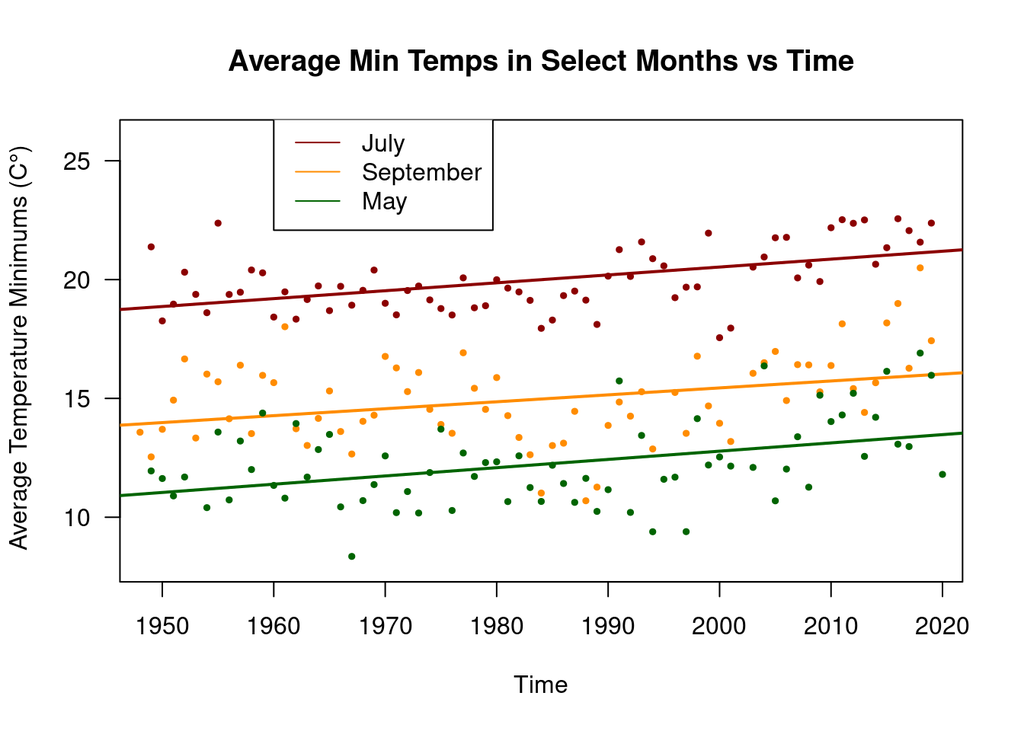

Graph 1: May, July, and September have been getting hotter in D.C. between 1948-2020. April and June, (not shown) also have similar, significant trends. My data across these months did not violate the assumptions of the linear model. Meeting these assumptions suggests that there is support for the interpretation of this model.

Table 1. Washington D.C., Late Spring and Summer Monthly Temperature Minimum Trends (1948-2020)

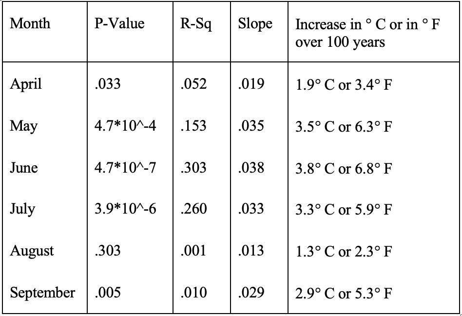

Table 1: Over a 100-year span, for significant slopes, temperatures have increased by, on average, 3.1 degrees Celsius (5.6 degrees Fahrenheit) in these months. Across these summer and late-spring months (excluding August,), p-values were all significant (p<.05) or very significant (p<.001). However, winter and fall months (not shown) had no significant correlations. Of the months in the table, many of their adjusted r-squared values were small, such as May’s and September’s, which means that our linear model does not account for the variation of the data that well; however, small r squared values do not refute the correlation between time and temperature.

From temperature minimum analyses, the bottom line is that other than in August, late spring and summer temperature minimums have been significantly getting hotter between 1948-2020 (p-values<.05). The linear model reveals that, for significant slopes, over a 100-year span, temperatures have increased by 3.1 degrees Celsius (5.6 degrees Fahrenheit) on average in these months. Hayhoe and Stoner (2015), who synthesized data from two other D.C. weather stations, corroborated these results independently. They predict that future minimum temperatures will increase even faster than 3.1 degrees Celsius (5.6 degrees Fahrenheit) over 100 years. By 2010, they suspect that summer minimums will be hotter by around 4.4 to 5.5 degrees Celsius (7.9 to 8.3 degrees Fahrenheit) (Hayhoe et al., 2015).

#### Daily Temperature Maximum Mixed Results

Although I found no significant temperature maximum changes from 1948 until 2020 using daily data, Hayhoe and Stoner’s (2015) analysis found that summer maximums will get hotter. More specifically, Hayhoe and Stoner’s projections indicate that summer temperature maximums, days with the extreme heat index, and heatwaves will all increase. Like their prediction for daily temperature minimums, the authors predict that summer daily temperature maximums will increase between 4.4 and 5.5 degrees Celsius (7.9 to 8.3 degrees Fahrenheit). They also projected that heatwaves will occur more frequently, last longer, and be more severe (Hayhoe et al., 2015).

#### Possible Misinterpretations of the Analysis

Although there is historical minimum summer warming in D.C., I would like to clarify that this warming is not necessarily a result of climate change; there are other variables at play. For example, D.C.’s tree loss between 1950 and 2020 has likely warmed the city because trees are good regulators of hot air (Harden, 2020). However, while climate change cannot be singled out as the single historical reason for D.C. warming trends, Hayhoe and Stoner (2015) show that global climate change will increase D.C.’s temperature. Therefore, there is reason to be concerned.

The data I used is also not perfect. For one, between 1948 and 1989 (41 years of our data), there is no record of the equipment that scientists used (“Daily Summaries…”, n.d.). For another, within the known dates, the station changed equipment eight times (“Daily Summaries…”, n.d.). Lastly, between 1989 to 2001, the station recorded data at one hour earlier than other dates (at 7 am as opposed to 8 am) (“Daily Summaries…”, n.d.). These inconsistencies produce uncertainties. Therefore, my data analysis should be taken with a grain of salt. That being said, regional models, as well as two D.C. weather stations, corroborate D.C. warming (Hayhoe et al., 2015). Because of this evidence, D.C. needs to assess warming ramifications.

### Are Heat’s Heath Implications Serious? Are these Implications Distributed Evenly?

At first glance, hotter summers may seem like an inconvenience, but, overall, no big deal. However, contrary to this initial reaction, hotter days and nights will determine the health and survival of many Washingtonians, especially Black and low-income residents.

Heat health effects are well documented in the US and globally, and the evidence is not good news for D.C. residents. During heatwaves, which Hayhoe and Stoner (2015) expect to be longer and more frequent in D.C., hot days shock people’s bodies, and warm nights prevent recovery (Peninah et al., 2017). Because of this physiological stress, in the US, higher maximum and minimum temperatures kills over 1,500 people each year and contribute to higher heat-related hospitalizations (Climate change and…“, 2016; Gregory, 2018). In fact, intense heat is the leading cause of extreme weather deaths in the US (more than hurricanes, tornados, etc.) (Climate change and…”, 2016). In the 2003 European heatwave alone, there were 70,000 excess deaths according to an epidemiological analysis by Robine et al. (2008).

Being a mid-Atlantic US city, D.C. is not excluded from heat’s effects. Although one may expect heat health effects to be most pronounced in hotter regions like the South, more northern cities, where people are less accustomed to extreme heat, have recently experienced some of the deadliest heat waves (“Climate change and…”, 2016). Furthermore, because of the well documented urban heat island effect, cities are typically hotter than rural areas. The EPA estimates that city daytime temperatures are around 1-7 degrees Fahrenheit higher, and nighttime temperatures are 2-5 degrees Fahrenheit higher (“Heat Island Effect”, 2020). In all, the evidence is overwhelming; D.C. residents will have to face the serious health consequences of heat, but who specifically will be hurt most?

In D.C., the answer will likely be Black and low-income residents. According to Vivek Chandras, an urban planner at Oregon State, “there’s an upwards of 15- to 20-degree Fahrenheit differences within a city” (Pearce, 2019). His research reveals that among these differences, there are strong correlations between lower-income neighborhoods and higher temperatures (Pearce, 2018). Although there has not been a formal analysis of such correlations in D.C., the following maps can idea of how heat and income are connected.

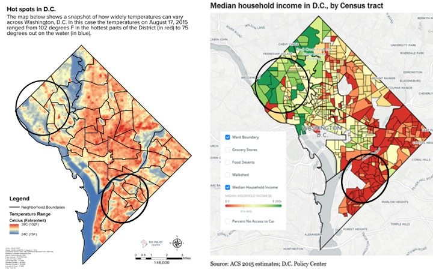

One driver for hotter temperatures in D.C. low-income and Black communities is less tree cover. Trees, along with providing other ecosystem benefits such as stormwater management and pollution removal, are natural heat regulators. According to the EPA, shade from tree canopies can reduce the heat of an area by 11-25 degrees Celsius (20-45 degrees Fahrenheit) (“Using Trees and…”, 2019). While air conditioning and urban redesign provide similar heat regulation benefits, trees do these services while also capturing carbon. No matter the reason, differences in heat not only raise the energy bills for low-income residents with fewer trees but also puts low-income people who live in less vegetated areas at an estimated five percent more risk of dying from heat-related causes, according to a review paper of epidemiological literature (Schinasi et al. 2017). The following analysis done by the nonprofit Casey Trees, that focuses on revitalizing D.C.’s tree canopy, reveals how income and tree coverage are correlated:

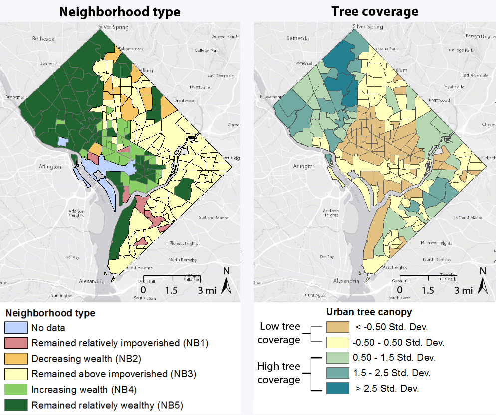

Not only do Black and low-income residents feel more heat, but they may also be more vulnerable to its effects. According to the CD.C., obesity is a risk factor for heat-related illnesses (“Heat Related Illness”, n.d. ). Black residents suffer from higher rates of obesity (1/3 of Black D.C. residents are obese compared with 1/10 white residents), making Black residents also more vulnerable to heat effects (King, 2016). In total, likely due to fewer trees in their neighborhoods, low-income, and Black residents live in hotter areas. Unfortunately, without proper mitigation, this heat exposure will lead to a greater risk of death and health problems.

### How are D.C. Activists Responding?

The good news is that according to Vivek Chandras, the same urban planner mentioned earlier, heat deaths are “very preventable deaths” (Pearce, 2018). Activist’s efforts across D.C.— including the city government, non-profits, and residents— have hoped to decrease urban heat by planting trees, especially in low-income neighborhoods, but there is still a long way to go.

The city government has partnered with D.C. activist groups like Casey Trees to reach a 40% tree canopy by 2032— right now, according to Harden (2020), the district is at 39%. This government partnered program is mainly focused on public planting sites such as parks and city tree lots (Harden, 2020). However, for the plan to work, officials rely on residents not to remove trees from private property (Harden, 2020). To minimize this tree removal, the government charges fines. To incentivize planting on private land, which is the majority of D.C. land, Casey Trees, in partnership with the D.C. government, offers either $50 or $100 in tree rebates for residents who plant a tree in their yard (“Tree Rebate”, 2019). Along with subsidizing these programs, the D.C. government created public cooling stations with AC across the district, providing safety for many residents, such as people experiencing homelessness. Lastly, the government has also created building restrictions that require energy efficiency and incentivize green roofs.

Overall, these programs are promising to curb the effects of heat; however, the D.C. government still has a lot of work to do. With public tree plots, the D.C. government has struggled to repair the unequal distribution of trees that hurts low-income and Black communities. According to a 2018 analysis by Chris Cioffi of government-owned tree lots using D.C. inventories, Black and low-income wards have higher proportions of unplanted tree lots (Cioffi, 2018). Specifically, Wards 5, 7, and 8, the lowest income wards with the highest percentage of Black residents, have 11%, 12%, and 10% empty tree lots compared with ward 2 and ward 3, the wealthiest wards, that have 1% and 4% empty tree boxes respectively (“Demographic and housing…”, 2011; Cioffi, 2018).

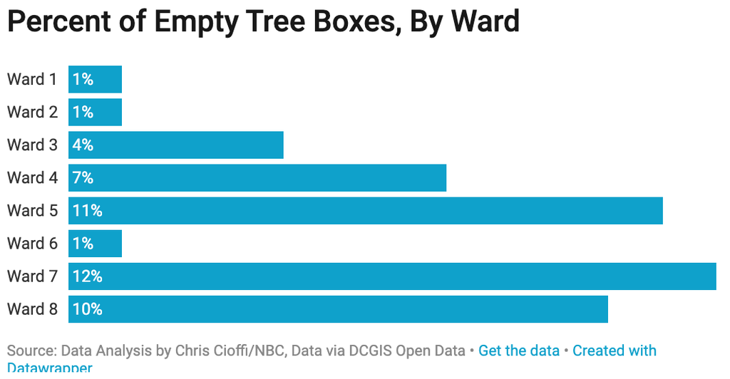

Image 4: Empty public tree boxes are predominantly in Wards 5,7,8, the lowest income Wards with the highest proportion of Black residents. Since 2008, nearly half tree box plantings have been in Ward 5,7, and 8 (Cioffi, 2018)

Along with not fully correcting past tree inequities, D.C. policy has struggled to disincentivize tree removal on private property. Around half of D.C. is private land, and, because there is diminished public land to plant trees, private tree planting is becoming increasingly important (Harden, 2020). However, private tree removal permits have increased in the last decade. In 2013, 713 permits for the removal of 990 trees were issued (Harden, 2020). By 2019, more than 1,500 permits were issued for 3,200 trees (Harden, 2020). Much of these removals can be attributed to development projects that officials, often with the backing of residents, have approved (Harden, 2020). However, these approved permits for development threaten the 40% tree canopy target that Casey Trees and the D.C. government want to reach.

When it comes to correcting inequality, there is a bigger problem than inadequate rebate programs: many Black people or low-income communities may not want trees. For example, during a Casey Trees planting event in Southeast D.C., not everyone was pleased to see the new plantings. Resident Ladawn Bynum, worried that increased greenery would enable crime. She said, “It’s not the trees’ fault, but a lot of people in this neighborhood don’t have the best intentions. So, the way it is I think is okay, because you can see what’s going on” (Elwell, 2017). The documentary City of Trees follows a D.C. green jobs initiative run by the group Washington Parks & People to replant trees in Ward 8. In the documentary, residents often opposed the group’s tree plans. Washington Parks & People learn this opposition immediately when someone slashes one group member’s car tires on their first day of planting at a specific park (Nelson, 2017). Additionally, one D.C. forester in the movie comments “I’ve looked at this area many, many times, and I could never get the community to buy into planting trees here”. The reality that many communities that could benefit from trees the most may not want them poses a serious problem in correcting inequalities in the city (Nelson, 2017).

One solution to this problem is promoting community involvement in tree projects. In the documentary, Washington Parks & People find the most success when they hire community members as part of their team (Nelson, 2017). With these new local employees, the group is better able to convince community members that the tree programs are useful (Nelson, 2017). Today, the organization is centered around education and partnership programs with the local community. Another form of community involvement is showcased by the urban planner Vivek Chandras who recruited an army of citizen scientists to collect urban heat island data (Pearce, 2018). By incorporating locals into the project, Chandras helped disseminate the importance of heat mitigation (Pearce, 2018). Education programs traditionally have focused on disseminating information rather than working alongside communities, but efforts like Chandras’s and the Washington Parks & People’s that incorporate citizens more into decision-making may be more impactful (Nelson, 2017). In total, activist groups like Casey Trees and Washington Parks & People should continue to pressure the city government to lead with programs that focus on citizen science while also trying to increase planting, reject tree removal permits meant for development, and increase rebate programs.

### Conclusion: What D.C. Residents Can Do

The D.C. government and non-profits need to increase planting in low-income neighborhoods, create better-funded rebate programs, and engage more involve more low-income and Black residents into their heat reduction plans. However, there are things that any resident in D.C. can do right now too. Non-profits like Casey Trees and Washington Parks and people require funding. Small donations can go a long way in correcting D.C.’s heat effects. Even more important than donations, residents need to be informed about the harms of heat and what can be done to mitigate these issues. On their website, Casey Trees provides a free program that teaches residents effective ways to raise awareness about the benefits of trees. Residents can also hold government officials accountable by sending testimonies to City Council. With engaged activists involved in community and government decisions, there is hope that the district will respond properly to climate change’s unequal harms.

In all, just like my heat stroke when I was ten, the realities of climate change’s heat effects are scary. Even if residents and the D.C. government plant trees, the district will still have incredibly high inequality rates and face many more environmental challenges that I was not able to cover due to space. The solution to problems as big as climate change and health inequality will require much greater systemic reform than only tree planting and community involvement initiatives. However, tree education and planting programs in low-income and Black D.C. neighborhoods would be a good start in the right direction.

### Citations

1. Ake, D. J. (2018). Photography. Retrieved October 14, 2020, from https://www.jdavidake.com/index/G0000hj.5rmBsffo
2. Climate change and extreme heat: What you can do to prepare (Rep. No. EPA 430-R-16-061). (2016). Washington, D.C.: Environmental Protection Agency.Retrieved October 14, 2020, from https://www.cD.C..gov/climateandhealth/pubs/extreme-heat-guidebook.pdf
3. Daily Summaries Station Details. (n.d.). Retrieved October 14, 2020, from https://www.ncD.C..noaa.gov/cdo-web/datasets/GHCND/stations/GHCND:USC00186350/detail
4. Demographic and Housing Profiles 2010 by Ward. (2011, May 11). Retrieved October 14, 2020, from https://planning.DC.gov/node/596612
5. Department of Energy & Environment: Environmental Services. (n.d.). Retrieved September 27, 2020, from https://doee.DC.gov/service/environmental-services
6. Elwell, J. (2017, November 13). Why Do D.C.’s Poorer Neighborhoods Have Fewer Trees? Retrieved October 14, 2020, from https://caseytrees.org/2017/11/d-c-s-poorer-neighborhoods-fewer-trees/
7. Gregory, N. (2018, September 05). How Hotter Nights Hurt Your Health. Retrieved September 27, 2020, from https://www2.calstate.edu/csu-system/news/Pages/Rise-in-nighttime-temperatures-and-health.aspx
8. Harden, J. (2020, March 27). D.C. planted nearly 80 trees a day to reach a canopy target. It’s running out of space. Retrieved September 27, 2020, from https://www.washingtonpost.com/DC-md-va/2020/03/27/tough-place-tree-live-DC-planted-nearly-80-trees-day-reach-canopy-target-its-running-out-space/?arc404=true
9. Hayhoe, K., & Stoner, A. (2015, April). Climate Change Projections for the District of Columbia (Rep.). Retrieved October 14, 2020, from https://doee.DC.gov/sites/default/files/DC/sites/ddoe/publication/attachments/Attachment%201%20.ARC_.Report_07-10-2015.pdf
10. Heat Related Illness (pp. 1-7, Rep.). (n.d.). CD.C.. Retrieved October 14, 2020, from https://www.cdc.gov/pictureofamerica/pdfs/picture_of_america_heat-related_illness.pdf
11. King, C. (2016, July). The Health of the African American Community in the District of Columbia: Disparities and Recommendations (Rep.). Retrieved October 14, 2020, from https://www.abfe.org/wp-content/uploads/2016/11/The-Health-of-the-African-American-Community-in-the-District-of-Columbia.pdf
12. Naveed, M. (2018, January 04). Income Inequality in D.C. Highest in the Country. Retrieved October 14, 2020, from https://www.D.C.fpi.org/all/income-inequality-DC-highest-country/
13. Nelson, A. (2017). Film Reviews: City of Trees & Trees in Trouble. Biohabitats, Xv(1). Retrieved October 14, 2020, from https://www.biohabitats.com/newsletter/urban-forestry/film-reviews-city-of-trees-trees-in-trouble/
14. Pearce, F. (2018, March 7). Urban Heat: Can White Roofs Help Cool World’s Warming Cities? Yale Environment 360. Retrieved October 14, 2020, from https://e360.yale.edu/features/urban-heat-can-white-roofs-help-cool-the-worlds-warming-cities
15. Robine, J., Cheung, S. L., Roy, S. L., Oyen, H. V., Griffiths, C., Michel, J., & Herrmann, F. R. (2008). Death toll exceeded 70,000 in Europe during the summer of 2003. Comptes Rendus Biologies, 331(2), 171-178. doi:10.1016/j.crvi.2007.12.001
16. Schinasi, L. H., Benmarhnia, T., & De Roos, A. J. (2018). Modification of the association between high ambient temperature and health by urban microclimate indicators: A systematic review and meta-analysis. Environmental research, 161, 168–180. https://doi.org/10.1016/j.envres.2017.11.004
17. Smith, R. (2017, August 08). D.C.’s heat islands. Retrieved October 14, 2020, from https://www.DCpolicycenter.org/publications/urban-heat-islands/
18. Smith, R. (2017, March 13). Food access in D.C is deeply connected to poverty and transportation. Retrieved October 14, 2020, from https://www.DCpolicycenter.org/publications/food-access-D.C.-deeply-connected-poverty-transportation/
19. Tree Rebate. (2019, January 11). Retrieved October 14, 2020, from https://caseytrees.org/resources/tree-rebate/.
20. Urban Forest Effects and Values September 2015 (pp. 1-39, Rep.). (2015). Casey Trees. Retrieved October 14, 2020, from https://caseytrees.org/wp-content/uploads/2017/03/iTree-2015-Report_English.pdf.
21. Using Trees and Vegetation to Reduce Heat Islands. (2019, December 16). Retrieved October 14, 2020, from https://www.epa.gov/heatislands/using-trees-and-vegetation-reduce-heat-islands
22. Washington D.C. Climate. (n.d.). Retrieved September 27, 2020, from http://www.city-data.com/us-cities/The-South/Washington-D-C-Geography-and-Climate.html